# IODS course project

Ari Voutilainen

# Introduction to Open Data Science - Course Project

## Thoughts about IODS2021

```r
date()
```

```
## [1] "Thu Dec 09 09:34:13 2021"
```

I noticed this course last year when it advertised itself in UEF’s Yammer.

So far, I have carried out the following tasks:

1. I watched the webinars by Garrett Grolemund regarding RStudio and GitHub.
2. I installed R, RStudio, and Git to my computer.
3. I created an account on GitHub, a GitHub repository for the IODS-project [https://github.com/atv475/IODS-project], and a course diary web page [https://atv475.github.io/IODS-project/].
4. I successfully completed R Short and Sweet on Nov 2, 2021.

*Now I am learning R Markdown*. At first, I struggled with it but, fortunately, I found some informative YouTube videos that showed me the very basics. I have never used R Markdown before.

The structure of IODS2021 is well-thought and clear so I believe the course will flow smoothly. However, I expected to hear more about **the reasoning of the course**. Why Open Data Science is important, and why should we learn these technical skills, such as RStudio?

## Linear regression and model validation

```r
date()
```

```
## [1] "Thu Dec 09 09:34:13 2021"
```

**FIRST, I carried out the data wrangling exercise and created the following R script.**

*This corresponds to the data wrangling part of Exercise 2.*

*#Ari Voutilainen #November 9, 2021. #R script for data wrangling in IODS2021 Exercise 2.*

- lrn14 <- read.table(“http://www.helsinki.fi/~kvehkala/JYTmooc/JYTOPKYS3-data.txt”, sep=", header=TRUE)
- dim(lrn14)
- str(lrn14)

*#LRN14 consists of 183 rows and 60 columns. #The last four columns are entitled as follows: Age, Attitude, Points, and gender.*

*#Creating variables deep, stra, and surf.*

- library(dplyr)
- deep_questions <- c(“D03”, “D11”, “D19”, “D27”, “D07”, “D14”, “D22”, “D30”,“D06”, “D15”, “D23”, “D31”)
- deep_columns <- select(lrn14, one_of(deep_questions))
- lrn14$deep <- rowMeans(deep_columns)
- strategic_questions <- c(“ST01”,“ST09”,“ST17”,“ST25”,“ST04”,“ST12”,“ST20”,“ST28”)
- strategic_columns <- select(lrn14, one_of(strategic_questions))
- lrn14$stra <- rowMeans(strategic_columns)
- surface_questions <- c(“SU02”,“SU10”,“SU18”,“SU26”, “SU05”,“SU13”,“SU21”,“SU29”,“SU08”,“SU16”,“SU24”,“SU32”)
- surface_columns <- select(lrn14, one_of(surface_questions))
- lrn14$surf <- rowMeans(surface_columns)

*#I found the name of the one_of function misleading. It does not select just one but all.*

*#Creating an analysis data set.*

- keep_columns <- c(“gender”,“Age”,“atti”, “deep”, “stra”, “surf”, “Points”)
- learning2014 <- select(lrn14, one_of(keep_columns))
- learning2014 <- filter(learning2014, Points > 0)

*#Now the analysis data set consists of 166 rows and 7 columns.*

*#Setting the working directory.*

- setwd(“C:/Users/ariv/Documents/IODS-project/IODS-project/data”)
- getwd()

*#Obs! There is an IODS-project folder inside an IODS-project folder on purpose.*

*#Saving the analysis data set.*

- ?write.csv
- write.csv(learning2014, file = “learning2014.csv”)
- read.csv(“learning2014.csv”)
- str(learning2014)
- head(learning2014)

**SECOND, I explored the structure of the learning2014 data set.**

*This corresponds to the data analysis part of Exercise 2, its 1. task.*

- setwd(“C:/Users/ariv/Documents/IODS-project/IODS-project/data”)
- read.csv(“learning2014.csv”)
- dim(learning2014)
- str(learning2014)
- head(learning2014)

The **learning2014** data set describes students in the Introduction to Social Statistics course in 2014. The number of students is 166, and all of them participated in the course exam.

The **learning2014** data set consists of seven variables:

1. *Gender*.
2. *Age* in years.
3. Global *attitude* toward statistics.
4. Mean answer to questions reflecting *deep learning*.
5. Mean answer to questions reflecting *strategic learning*.
6. Mean answer to questions reflecting *surface learning*.
7. *Points* achieved in the exam.

**THIRD, I explored the variables of the learning2014 data in more detail.**

*This corresponds to the data analysis part of Exercise 2, its 2. task.*

```r
library(readr)
setwd("C:/Users/ariv/Documents/IODS-project/IODS-project/data")
learning2014 <- read_csv("learning2014.csv",
    col_types = cols(...1 = col_skip(), gender = col_factor(levels = c("F",
        "M")), Age = col_number(), atti = col_number(),
        deep = col_number(), stra = col_number(),
        surf = col_number(), Points = col_number()))
```

```
## * `` -> ...1
```

```r
View(learning2014)
summary(learning2014$gender)
```

```
##   F   M
## 110  56
```

```r
summary(learning2014$Age)
```

```
##    Min. 1st Qu.  Median    Mean 3rd Qu.    Max.
##   17.00   21.00   22.00   25.51   27.00   55.00
```

```r
summary(learning2014$atti)
```

```
##    Min. 1st Qu.  Median    Mean 3rd Qu.    Max.
##   1.400   2.600   3.200   3.143   3.700   5.000
```

```r
summary(learning2014$deep)
```

```
##    Min. 1st Qu.  Median    Mean 3rd Qu.    Max.
##   1.583   3.333   3.667   3.680   4.083   4.917
```

```r
summary(learning2014$stra)
```

```
##    Min. 1st Qu.  Median    Mean 3rd Qu.    Max.
##   1.250   2.625   3.188   3.121   3.625   5.000
```

```r
summary(learning2014$surf)
```

```
##    Min. 1st Qu.  Median    Mean 3rd Qu.    Max.
##   1.583   2.417   2.833   2.787   3.167   4.333
```

```r
summary(learning2014$Points)
```

```
##    Min. 1st Qu.  Median    Mean 3rd Qu.    Max.
##    7.00   19.00   23.00   22.72   27.75   33.00
```

Of the 166 students, 110 were female. The mean (range) age of students was 25.5 (17-55) years. Their global attitude toward statistics ranged from 1.4 to 5.0 with a mean value of 3.1. Variables describing deep, strategic, and surface learning resulted in the following mean (range) values, respectively: 3.7 (1.6-4.9), 3.1 (1.3-5.0), and 2.8 (1.6-4.3). In the variables reflecting attitude and learning strategies, the scale ranges from 1 to 5.

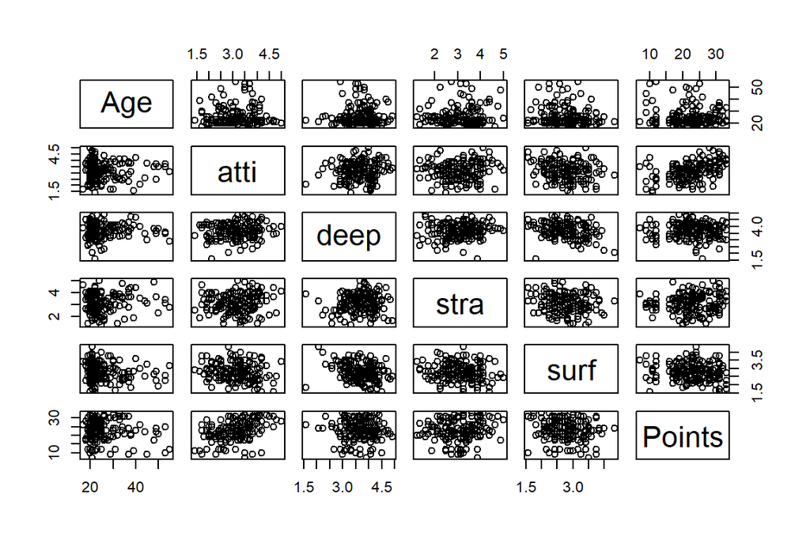

```r
pairs(learning2014[-1])
```

Based on a visual inspection of the scatter plot matrix, exam points correlated most evidently with students’ attitude.